# Vignette of R packages in HMMM Data Analysis

September 20, 2017

## *HMMMM…*

- Tidal zone development for the Delaware and Schuylkill Rivers
- Tide and SLR Impact Analysis on Regulator Critical Elevations
- Regulator outfall level breakout detection
- Centralized H&H database

## Introduction of R

**What's R?**

- A Data Analysis Tool

```
"R is the Excel on Steroids."
        -- Rajesh Rajan (2017)
```

- A Programming Language

**What's good in R?**

- vectored operation
- 10000+ open-source packages
  - community supported
  - CRAN system

[figure not shown]

## Tidal zone development for the Delaware and Schuylkill Rivers

**BACKGROUND**

Tide along the Delaware and Schuylkill rivers is shifted up to an hour

**OBJECTIVES**

Categorize the Delaware and Schuylkill rivers in Philadelphia into tidal zones, so that each regulator outfall can have a more representative tide time-series as the boundary condition

**METHODOLOGY**

- Harmonic analysis for nearby NOAA stations
- Interpolation of the M2 constituent

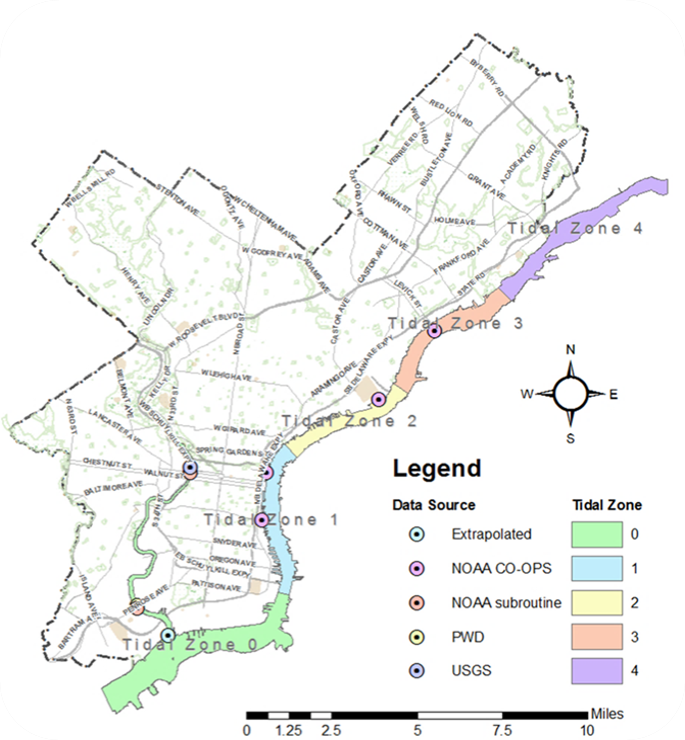

## Results

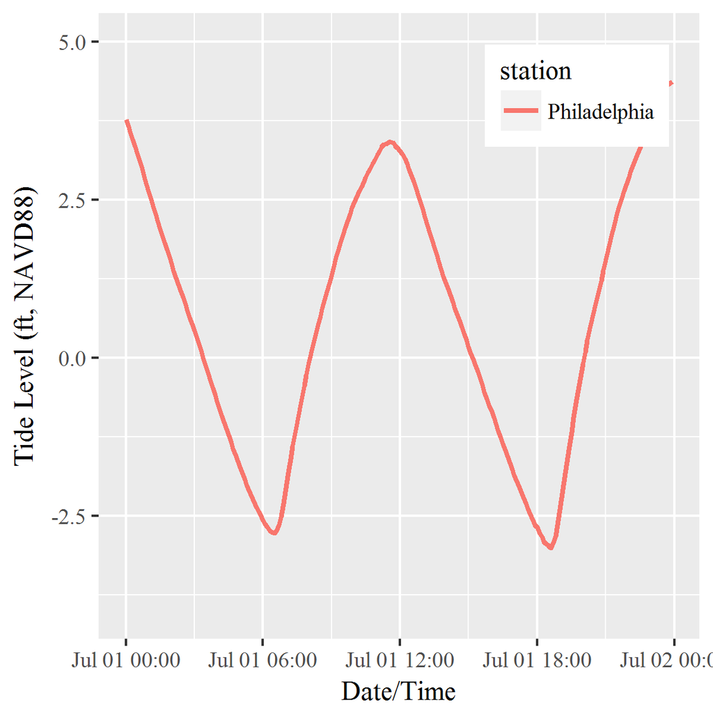

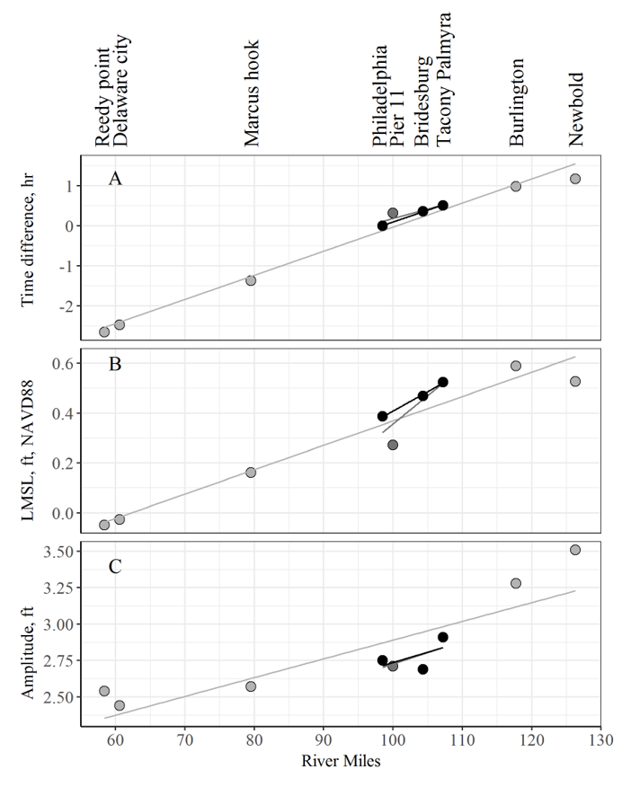

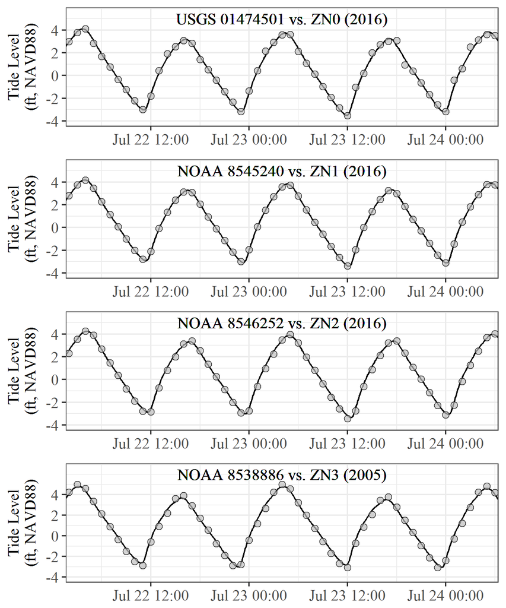

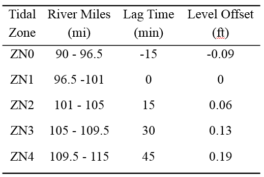

[interactive chart not shown]

## Environmental Packages

**`rnoaa` package**: R interface to NOAA climate data

```r
library(rnoaa)
tide <- coops_search(
             begin_date = 20161201,
             end_date = 20161231,
             station_name = 8545240,
             product ='water_level',
             datum = 'NAVD',
             units = 'english',
             time_zone = 'lst')[[2]]
```

**`TideHarmonics` package**: Implements harmonic analysis of tidal and sea-level data with over 400 harmonic tidal constituents (`T-tide` equivalent in R)

```r
library(TideHarmonics)
hfit <- ftide(tide$v, tide$t, hc7)
```

```
Harmonics:
    amplitude  phase      sine      cosine
M2  2.57826    58.60719   2.20085   1.34302
K2  0.56254   207.66470  -0.26118  -0.49823
N2  0.49710    33.30092   0.27293   0.41548
K1  0.44734    52.71923   0.35594   0.27096
P1  0.27295   313.78100  -0.19706   0.18885
S2  0.24909   189.67717  -0.04187  -0.24554
O1  0.17018    21.34632   0.06195   0.15851
```

## Time-series handling

**`zoo` package**: Z's Ordered Observations

- classes `zoo`, `zooreg`
- for both **irregular** and regular time-series

```r
zoo(x, order.by, frequency, calendar)
```

- `na.*()` : impute time-series by various methods. example
- `roll*()`: apply rolling functions

```r
rollmean(nottem,2)
rollapply(nottem, 2, mean, by=3)
```

**`xts` package**: extended zoo/ts

- robust subsetting:

```r
   # subsets data within time range
   xts["T06:00/T18:00"]
   # subsets data within date range
   xts["2012-01-01/2012-03-21"]
   # subsets data by start/end date
   xts["/2011"], xts["2011/"]
   # subsets by 'IS NOT' condition
   xts[-xts[daterange, which.i=T],]
```

- required by the `dygraphs` package

**`lubridate` package**: Dates and times made easy

- `parse_date_time(), fast_strptime(), ymd_hms()`: parse character vector to POSIXct

**Reminder**: the default time zone is 'UTC' instead of local time zone

- `rollback()`: roll back date to last day of previous month, or the first day of this month
- `with_tz(), force_tz()`: time zone adjustment

**`dygraphs` package**: interactive time-series plots

- based on the `dygraphs` JavaScript charting library

```r
dygraphs(data,
         main = NULL,
         xlab = NULL, ylab = NULL,
         periodicity = NULL,
         group = NULL,
         elementId = NULL,
         width = NULL, height = NULL)
```

- data must be `xts` class or equivalent
- use `mts` object for multi- time-series
- returns a HTML widget

## Tide and SLR Impact Analysis on CSO Regulators

**OBJECTIVES**

Evaluate the impact of tide levels on Philadelphia's Combined Sewer system:

- demostrate the hydraulic critical elevations of regulators in an interceptor system
- generate the CDFs of hydraulic critical elevations for selected interceptor systems

**IMPLEMENTATION**

- developed in R's shiny framework
- plots made in ggplot2, with some hacks to show tool-tips
- deployed on a shiny server, hosted by Amazon Web Service (AWS)

http://52.90.33.211/DamElevCDF/

[interactive chart not shown]

## Data Visualization Packages

**`shiny` package**: a simple web apps development framework in R

**shiny apps**

- deployable on local machine, remote server, and cloud
- UI.R + server.R + global.R

**shiny server**

- host shiny apps (Linux only for now)
- accessible from any browser

**Reactivity**

```r
server <- function(input, output) {
  output$distPlot <- renderPlot({
    hist(rnorm(input$obs),
         col = 'darkgray', border = 'white')
  })
}
ui <- fluidPage(
  sidebarLayout(
    sidebarPanel(
      sliderInput(
          "obs", "Number of observations:",
          min = 10, max = 500, value = 100)
    ),
    mainPanel(plotOutput("distPlot"))
  )
)
shinyApp(ui = ui, server = server)
```

**`ggplot2` package**: creating graphics based on 'The Grammar of Graphics'

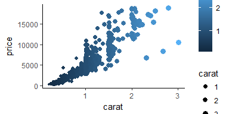

```r
library(ggplot2)
d<- diamonds[sample(nrow(diamonds), 1000),]

ggplot(d)+
    geom_point(aes(x=carat, y=price,
                   color=carat,size=carat))+
    theme_classic()
```

**`ggedit` package**: a shiny widget for setting ggplot themes and layer aesthetics

- `ggedit(p)`: bring up the editor GUI for the ggplot object
- `rgg()`: replace a layer from the ggplot object

**`grid`, `gridExtra` packages**: useful to combine ggplots

```r
gA <- ggplotGrob(ZN0.valid)
gB <- ggplotGrob(ZN1.valid)
gB$widths <- gA$widths
grid.newpage()
g <- grid.arrange(gA,gB, ncol=1, heights=unit(rep(1.5,2),'in'), widths=unit(5,'in'))
```

**`plotly` package**:

- D3.js html widgets, easy to embed in documents
- includes various types of charts https://plot.ly/r/
- `ggplotly()`: wrapper for ggplot

```r
library(plotly)
set.seed(100)
d <- diamonds[sample(nrow(diamonds), 1000),]

p <- plot_ly(d,
             x = ~carat,
             y = ~price,
             color = ~carat,
             size = ~carat,
             text = ~paste("Clarity: ",
                           clarity))
```

[interactive chart not shown]

## `ggvis` package

Create interactive graphics with a syntax similar to ggplot2

- leverage shiny's infrastructure, e.g., sliders, buttons
- still under development (v0.4 now), may experiencing dramatic syntax change

http://ggvis.rstudio.com/

```r
library(ggvis)
mtcars %>%
    ggvis(x = ~wt, y = ~mpg) %>%
    layer_smooths(se=TRUE,
                  opacity := 0.5,
                  opacity.hover := 0.75) %>%
    layer_points(fill = ~factor(cyl),
                 size := 50,
                 size.hover := 200) %>%
    set_options(hover_duration = 250,
                height = 300,
                width = 500)
```

## `googleVis` package

- utilizing Google charting API
- primarily for business intelligence, including many intersting types of charts, maps, and tables

https://developers.google.com/chart/interactive/docs/gallery

```r
op <- options(gvis.plot.tag = 'chart')

Anno <- gvisAnnotationChart(
            Stock,
            datevar="Date",
            numvar="Value",
            idvar="Device",
            titlevar="Title",
            annotationvar="Annotation",
            options=list(
              width=800, height=350,
              fill=10, displayExactValues=TRUE,
              colors="['#0000ff','#00ff00']")
)
plot(Anno)
```

## Regulator outfall levels breakout and drift detection

**BACKGROUND**

- Water levels at regulators are monitored by PWD
- Over the time the sensor may be drifted, ragged, or function abnormally
- bad level reading impairs data analysis results, e.g., CSOcast

**OBJECTIVES**

Develop a routine task that checks the outfall levels for the past 6 months, and raise a flag when possible data anomaly or drift is detected.

## shift-in-trend detection

**`BreakoutDetection` package**

- breakouts: unexpected ramp up/down or mean shift; longer, trendy changes
- `breakout()`: detect the existence of anomalies/outliers of uni-variate time series.
  - algorithm: Energy Divisive with Medians

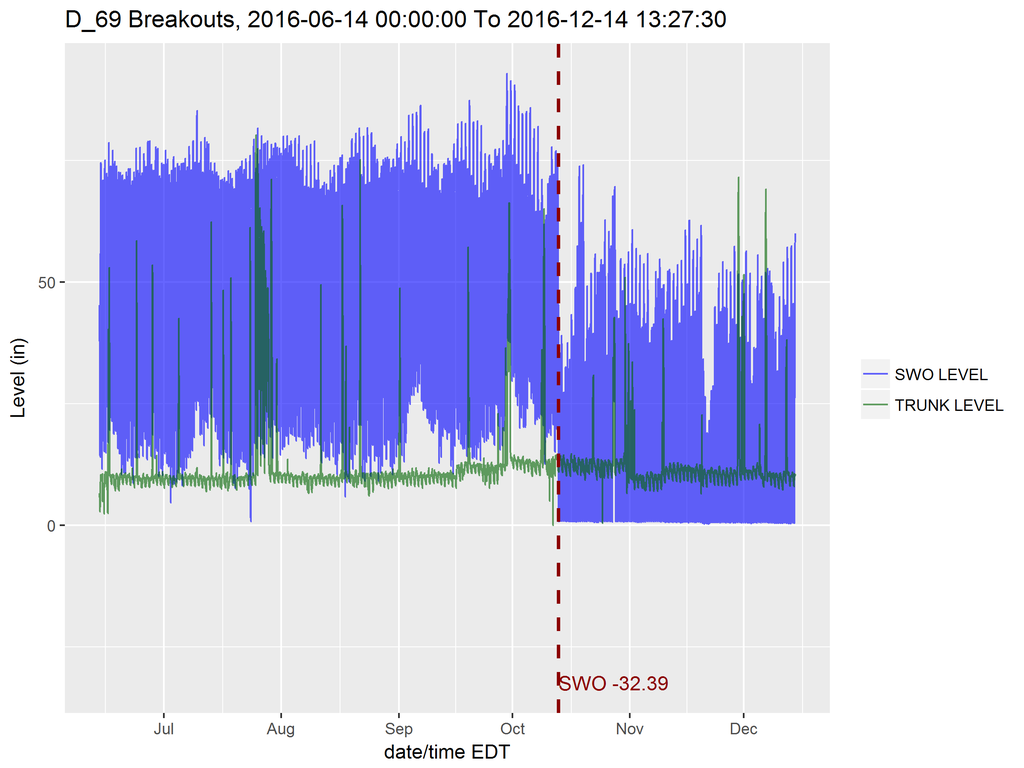

```r
breakout(
    # time-series, either numeric or data frame
    Z,
    # equals 30 days of data,
    # i.e., the shift must last more than 30 days
    min.size = 720,
    # multi change point analysis, vs. 'amoc'
    method = 'multi',
    # default
    degree=1,
    # default, but cannot be omitted
    beta=0.008,
    # threshold = 25% change, default
    percent=0.25,
    # generate a ggplot in output
    plot=TRUE
)
```

**`AnomalyDetection` package**

- data anomaly: data over or below expected value seasonally (global) or stationary (local); sudden spikes or dips
- Seasonal Hybrid ESD Test: built upon the Generalized ESD (Extreme Studentized Deviate) test, can detect both local and global outliers

```r
AnomalyDetectionTs(x, max_anoms = 0.1, direction = "pos", alpha = 0.05,
                   only_last = NULL, threshold = "None", e_value = FALSE,
                   longterm = FALSE, piecewise_median_period_weeks = 2,
                   plot = FALSE, y_log = FALSE, verbose = FALSE,
                   xlabel = "", ylabel = "count", title = NULL)
```

**`RSiteCatalyst` package**

- includes an anomaly detection feature via Adobe's Analytics Reporting API

## Parallel computing

*Suitable for:*

- multi-core processors
- repetitive but independent jobs

*Work flow:*

- Create a cluster (a collection of “workers”), allocate and register resources (CPU, memory)
- distribute jobs evenly to each worker
- assemble returned values from each worker, consolidate results as output
- close the cluster, release resources

**Cluster implementation:**

- Parallel Socket Cluster (PSOCK) : only loads base packages with no variables from current environment; use custom functions to 'export' variables, functions, libraries to the runtime environment by Value
  - Windows and Linux/Mac
  - `doParallel` package
- Fork: divide in branches and go separate ways, and all environment variables are automatically linked by Ref (also saves memory)
  - Linux/Mac only
  - `doSnow`, `doMC` package

## Implementation

`doParallel` + `foreach`:

- `makeCluster()`
- `registerDoParallel()`
- `foreach(iterator,...)`
  - `%dopar% EXPR`
  - `%do% EXPR`
- `stopCluster()`

`Parallel`:

- `clusterExport()`
- `parLapply()`

Microsoft R Open (MRO):

- `BLAS` and `LAPACK` packages via Intel Math Kernel Library (MKL)
- no need to modify code

## Example: Telog data Download

**Parallel method:**

```r
# Calculate the number of cores
no_cores <- detectCores() - 1
# create cluster
cl <- makeCluster(no_cores,type='PSOCK')
registerDoParallel(cl)

# download data in multi-threads mode
res.list <- foreach(
    x = 1:nrow(site_list),
    .packages = c("RODBC", "lubridate"),
    .combine = list,
    .multicombine = T,
    .maxcombine = nrow(site_list)
) %dopar% {
    telog_dl(
        site = site_list$site[x],
        measurement = site_list$meas[x],
        start_Dtime =  start_Dtime,
        end_Dtime = end_Dtime
    )
}
stopCluster(cl)
```

**Sequential method:**

```r
res.list = list()
for (i in 1:nrow(site_list)){
    res.list[i] <- telog_dl(
        site = site_list$site[i],
        measurement = site_list$meas[i],
        start_Dtime =  start_Dtime,
        end_Dtime = end_Dtime)
}
```

## Centralized H&H database

## OBJECTIVES

- Build a PostgreSQL database for H&H data
  - Extract data: from Excel, Access, and NOAA API
  - Transform data: Consolidate existing data, tidy data
  - Load data: import data to the database
- Develop a workflow for updating the database
- Database management: backup, restore
- Build a front-end (Dashboard, views)
  - shiny App
  - deployment
- Integrate with other apps
  - Post-storm analysis

## Excel readability

**`readxl` package**

- `read_excel()`: blazing fast on xlsx, fast on xls
- may hang on old xls files

**`XLConnect` package**

- java dependent, can be slow or crash on large files
- `readWorksheetFromFile()`: fast, but cannot handle datetime correctly

**`xlsx` package**

- java dependent, can be slow or crash on large files
- `read.xlsx()`: very slow
- `read.xlsx2()`: fast, but won't resolve formulas

**Python `xlrd` library**

- supports xls, xlsx, and xlsm
- very fast
- requires Python knowledge

## Data manipulation

**`tidyverse` package**: a collection of data manipulation packages that share common philosophies and are designed to work together

**`dplyr` package**:

- `select(), slice(), filter(), arrange()`
- `mutate(), transmute()`
- `group_by(), summarize()`
- `left_join(), right_join(), inner_join(),...`
- `intersect(), union(), setdiff()`
- `bind_rows(), bind_cols()`

**`tidyr` package**:

- `gather(), spread()`
- `separate(), unite()`

**`purrr` package**:

- **functional programming**: split a data frame into pieces, apply a process to each piece, e.g., fit a model, then summaries/extract results
- `map()`: `*apply()` with uniform syntax

```r
library(tidyverse)
mtcars %>%
  split(.$cyl) %>%
  map(~ lm(mpg ~ wt, data = .x)) %>%
  map(summary) %>%
  map_dbl("r.squared")
```

**`ggplot2` package**

**`readr` package** : read data from various formats

**`data.table` package**: subset rows, select and compute on columns and perform aggregations by group

- fast operation via:
  - Radix sort
  - Binary search
  - native-C
- large dataset capability
- inherits from `data.frame` class
- `fread()` : blazing fast data reader
- `DT[i, j, by]`: SQL style data manipulation
  - `i == WHERE`
  - `j == SELECT`
  - `by == GROUP_BY`
- join data.tables
  - inner join: `Y[X, on='a', nomatch=0L]`
  - nonequi join: `X[Y, on=c("x>=a", "y<=b")]`
  - rolling join: `X[Y, roll=T]`

## Database Connectivity

**`RODBC` package**

- `odbc*()`
  - `odbcConnect()`
  - `odbcConnectAccess()`
  - `odbcDriverConnect()`
  - `odbcClose()`
- `sql*()`
  - `sqlTables()`
  - `sqlQuery()`
  - `sqlSave()`

**`RPostgreSQL` package (dependent to `DBI`)**

- `dbDriver()`
- `dbConnect()`
- `dbWriteTable()`
- `dbGetQuery()`
- `dbExecute()`
- `dbDisconnect()`
- `dbUnloadDriver()`

## Documentation

**R markdown**

- markdown syntax
- quickly generate interactive documents

**R notebook**

- cache results
- good for reproducible research

**R Shiny**

- Interactive
- Web-based Analytics

**R presentation**

- `Rpres`: for quick, simple slides
  - "Battery Included"
- `ioslides` (HTML)
  - code highlighting
  - Presenter mode
- `slidy` (HTML)
- `reveal.js` (HTML)
- `beamer` (pdf)

## references

https://support.rstudio.com/hc/en-us/articles/201057987-Quick-list-of-useful-R-packages

https://cran.r-project.org/web/views/Environmetrics.html

https://cran.r-project.org/web/views/TimeSeries.html

http://randyzwitch.com/twitter-breakoutdetection-r-package-evaluation/

http://rstudio.github.io/shiny/tutorial/#inputs-and-outputs

https://jennybc.github.io/purrr-tutorial/

## Thank you!

[figure not shown]

Hao Zhang, Ph.D.

hao.zhang@phila.gov